Seung Park

2021-12-18

[figure not shown]

수업시간에 배운내용을 활용하여 dacon 대회에 참여해보았습니다 https://dacon.io/competitions/official/235857/overview/description

# 1 서론

2021.11.26일까지의 자료를 활용하여 KOSPI200, KOSDAQ150 총 370개 기업의 11.29~12.3일 주식종가를 예측해보고자 함

# 2 방법론 소개

# 3 데이터 소개

대회에서 제공된 stock_list에는 대회에서 예측하고자하는 370개 상장기업의 종목명, 종목코드, 상장시장등의 정보가 기입되어 있었음

```python
path = '/Users/spark/OneDrive/ps/Dacon/stock/data'
list_name = 'stock_list.csv'

stock_list = pd.read_csv(os.path.join(path,list_name))
stock_list['종목코드'] = stock_list['종목코드'].apply(lambda x : str(x).zfill(6))
stock_list.columns=['name','code','market']
stock_list
```

```
##          name    code  market
## 0        삼성전자  005930   KOSPI
## 1      SK하이닉스  000660   KOSPI
## 2       NAVER  035420   KOSPI
## 3         카카오  035720   KOSPI
## 4    삼성바이오로직스  207940   KOSPI
## ..        ...     ...     ...
## 365      맘스터치  220630  KOSDAQ
## 366        다날  064260  KOSDAQ
## 367   제이시스메디칼  287410  KOSDAQ
## 368   크리스에프앤씨  110790  KOSDAQ
## 369     쎄트렉아이  099320  KOSDAQ
##
## [370 rows x 3 columns]
```

위 종목코드 정보를 활용하여 Python FinanceDataReader패키지를 활용 2021.5.1부터 2021.11.26까지의 주가정보를 다운

```
{python}
start_date = '20210501'
end_date = '20211126'
path1='/Users/ps712/OneDrive/ps/Dacon/stock/data5/'
for code in tqdm(stock_list['code'].values):
  stock= fdr.DataReader(code, start = start_date, end = end_date)
  stock.to_csv(os.path.join(path1,code), index=True)
tqdm
```

# 4 분석결과 및 해석

## 4.1 R의 TTR 패키지 이용하여 preprocessing

6개의 Indicator중 Will값 제외(수치의 절대값이 계속증가하므로 제외) FastK와 FastD값을 제외(주가변동이 없을 경우 NA값 발생) 6개 위3개를 제외한 RSI, MACD, CCI 총3개의 Indicator값만 사용

```
{r}
stock_list=py$stock_list
for (i in 1:370){
  setwd('/Users/ps712/OneDrive/ps/Dacon/stock/data5/')
  file=stock_list[i,2]
  stock=as.xts(read.zoo(file, sep=",", h=T))
  Price <- stock[,4]
  HLC=matrix(c(stock[,2], stock[,3], stock[,4]), nrow=length(stock[,2]))

  r = diff(log(Price)) #예측하고자하는 값으로 로그 수익률
  rsi = RSI(Price)
  MACD = MACD(Price)
  macd= MACD[, 1]
  #will =williamsAD(HLC)
  cci <- CCI(HLC)
  #STOCH <-stoch(HLC,nFastK = 14)
  #stochK <-STOCH[,1]
  #stochD <-STOCH[,2]
  st = xts(x= matrix(c(as.numeric(rsi), cci, as.numeric(macd), r, Price), nrow=length(stock[,2])), order.by=index(r))
  colnames(st)=c("RSI","CCI","MACD", "Return","Price")

  file=stock_list[i,2]
  setwd('/Users/ps712/OneDrive/ps/Dacon/stock/data6/')
  write.zoo(st, file=file,index.name=stock_list[i,2],row.names=FALSE, col.names=TRUE,sep=",")}
```

## 4.2 python에서 LSTM으로 5일치 Feature생성

11.29~12.3의 주식수익률을 예측하기위해 TTR패키지를 통해 생성된 3개의 Indicator를 LSTM을 사용하여 11.29~12.3 5일치 predictdata(targetdata)를 생성함

```
{python include=FALSE}

path2 = '/Users/ps712/OneDrive/ps/Dacon/stock/data6/'
path3 = '/Users/ps712/OneDrive/ps/Dacon/stock/data7/'

for code in tqdm(stock_list['code'].values):
    stock= pd.read_csv(os.path.join(path2,code))
    df=stock[max(stock.isnull().sum()):]
    #RSI
    data = df.filter(['RSI'])
    dataset = data.values
    training_data_len = int(np.ceil( len(dataset) - 5))

    scaler = MinMaxScaler(feature_range=(0,1))
    scaled_data = scaler.fit_transform(dataset)

    train_data = scaled_data[0:int(training_data_len), :]

    x_train = []
    y_train = []

    for i in range(5, len(train_data)):
        x_train.append(train_data[i-5:i, 0])
        y_train.append(train_data[i, 0])
        if i<= 6:
            print()

    x_train, y_train = np.array(x_train), np.array(y_train)
    x_train = np.reshape(x_train, (x_train.shape[0], x_train.shape[1], 1))

    model = Sequential()
    model.add(LSTM(128, return_sequences=True, input_shape= (x_train.shape[1], 1)))
    model.add(LSTM(64, return_sequences=False))
    model.add(Dense(25))
    model.add(Dense(1))
    model.compile(optimizer='adam', loss='mean_squared_error')

    model.fit(x_train, y_train, batch_size=1, epochs=1,verbose=0)

    test_data = scaled_data[training_data_len - 5: , :]

    x_test = []
    y_test = dataset[training_data_len:, :]
    for i in range(5, len(test_data)):
        x_test.append(test_data[i-5:i, 0])

    x_test = np.array(x_test)
    x_test = np.reshape(x_test, (x_test.shape[0], x_test.shape[1], 1 ))

    predictions = model.predict(x_test)
    predictions = scaler.inverse_transform(predictions)

    predictions= pd.DataFrame(predictions, columns=['RSI'],index=[123,124,125,126,127])
    predictions
    RSI = pd.DataFrame(data[:training_data_len])

    RSI_new = RSI.append(predictions)
    RSI_new.columns=["RSI_New"]

    new_df = pd.concat([df,RSI_new], axis=1)

    #CCI

    data = df.filter(['CCI'])
    dataset = data.values
    training_data_len = int(np.ceil( len(dataset) - 5))

    scaler = MinMaxScaler(feature_range=(0,1))
    scaled_data = scaler.fit_transform(dataset)

    train_data = scaled_data[0:int(training_data_len), :]
    x_train = []
    y_train = []

    for i in range(5, len(train_data)):
        x_train.append(train_data[i-5:i, 0])
        y_train.append(train_data[i, 0])
        if i<= 6:
            print(x_train)
            print(y_train)
            print()

    x_train, y_train = np.array(x_train), np.array(y_train)
    x_train = np.reshape(x_train, (x_train.shape[0], x_train.shape[1], 1))

    model = Sequential()
    model.add(LSTM(128, return_sequences=True, input_shape= (x_train.shape[1], 1)))
    model.add(LSTM(64, return_sequences=False))
    model.add(Dense(25))
    model.add(Dense(1))
    model.compile(optimizer='adam', loss='mean_squared_error')

    model.fit(x_train, y_train, batch_size=1, epochs=1,verbose=0)

    test_data = scaled_data[training_data_len - 5: , :]

    x_test = []
    y_test = dataset[training_data_len:, :]
    for i in range(5, len(test_data)):
        x_test.append(test_data[i-5:i, 0])

    x_test = np.array(x_test)

    x_test = np.reshape(x_test, (x_test.shape[0], x_test.shape[1], 1 ))

    predictions = model.predict(x_test)
    predictions = scaler.inverse_transform(predictions)

    predictions= pd.DataFrame(predictions, columns=['CCI'],index=[123,124,125,126,127])

    CCI = pd.DataFrame(data[:training_data_len])

    CCI_new = CCI.append(predictions)
    CCI_new.columns=["CCI_New"]

    new_df = pd.concat([new_df,CCI_new], axis=1)

    #MACD

    data = df.filter(['MACD'])
    dataset = data.values
    training_data_len = int(np.ceil( len(dataset) - 5))

    scaler = MinMaxScaler(feature_range=(0,1))
    scaled_data = scaler.fit_transform(dataset)

    train_data = scaled_data[0:int(training_data_len), :]

    x_train = []
    y_train = []

    for i in range(5, len(train_data)):
        x_train.append(train_data[i-5:i, 0])
        y_train.append(train_data[i, 0])
        if i<= 6:
            print(x_train)
            print(y_train)
            print()

    x_train, y_train = np.array(x_train), np.array(y_train)

    x_train = np.reshape(x_train, (x_train.shape[0], x_train.shape[1], 1))

    model = Sequential()
    model.add(LSTM(128, return_sequences=True, input_shape= (x_train.shape[1], 1)))
    model.add(LSTM(64, return_sequences=False))
    model.add(Dense(25))
    model.add(Dense(1))
    model.compile(optimizer='adam', loss='mean_squared_error')

    model.fit(x_train, y_train, batch_size=1, epochs=1,verbose=0)

    test_data = scaled_data[training_data_len - 5: , :]

    x_test = []
    y_test = dataset[training_data_len:, :]
    for i in range(5, len(test_data)):
        x_test.append(test_data[i-5:i, 0])

    x_test = np.array(x_test)

    x_test = np.reshape(x_test, (x_test.shape[0], x_test.shape[1], 1 ))

    predictions = model.predict(x_test)
    predictions = scaler.inverse_transform(predictions)


    predictions= pd.DataFrame(predictions, columns=['MACD'],index=[123,124,125,126,127])
    MACD = pd.DataFrame(data[:training_data_len])

    MACD_new = MACD.append(predictions)
    MACD_new.columns=["MACD_New"]

    new_df = pd.concat([new_df,MACD_new], axis=1)

    new_df = new_df.drop([code,'RSI','CCI','MACD'], axis=1)

    new_df.to_csv(os.path.join(path3,code), index=True)
```

## 4.3 370개 기업중 1개의 기업(‘015760’ 한국전력)을 샘플로 선정

```r
setwd("/Users/spark/OneDrive/ps/Dacon/stock/data7")
stock_list=py$stock_list
(file=stock_list[24,2])
```

```
## [1] "015760"
```

```r
total=read.csv(file)
nrow=length(total[,2])
rsi= data.frame(total["RSI_New"])
cci=data.frame(total["CCI_New"])
macd=data.frame(total["MACD_New"])
r=data.frame(total["Return"])
```

## 4.4 Input(2021.5.1~2021.11.26) Target(11.29~12.3)분리

```r
Input = matrix(c(as.numeric(rsi[1:(nrow-6),1]), as.numeric(cci[1:(nrow-6),1]), as.numeric(macd[1:(nrow-6),1])), nrow=(nrow-6))
Target = matrix(c(r[2:(nrow-5),1]), nrow=(nrow-6))

InputTest=matrix(c(as.numeric(rsi[(nrow-5):(nrow-1),1]), as.numeric(cci[(nrow-5):(nrow-1),1]), as.numeric(macd[(nrow-5):(nrow-1),1])),nrow=5)
TargetTest=matrix(c(as.numeric(r[(nrow-4):(nrow),1])), nrow=5)

trainingdata=cbind(Input, Target)
colnames(trainingdata)=c("RSI", "CCI", "MACD", "Return")
trainingdata=na.omit(trainingdata)


Testdata=cbind(InputTest,TargetTest)
colnames(Testdata)=c("RSI","CCI","MACD", "Return")
```

## 4.5 Input data를 Train-Valid(80-20% ratio)분리

```r
length=length(trainingdata[,1])
trainIndex <- createDataPartition(1:length, p=.8, list=F)
Train <- trainingdata[trainIndex, ]
Valid <- trainingdata[-trainIndex, ]
```

## 4.6 best.mae산정하여 저장

```
{r include=FALSE}
best.network=matrix(0,2)
best.mae=1
# hyper-parameter settings
# size i: hidden layer에 있는 artificial neuron의 수
# decay j: parameter, weight regularization
for (i in seq(10, 100, 5)) for (j in c(0.01, 0.001, 0.0001)) {
  Fit=nnet(Return ~ RSI + CCI + MACD, data = Train, maxit=1000, size=i, decay=j, linout=TRUE)
  Predict=predict(Fit, newdata=Valid)
  mae1=mean(abs(Predict-Valid[,4]))
  if (mae1<best.mae) {
    best.network[1]<-i
    best.network[2]<-j
    best.mae=mae1
  }
}
```

## 4.7 모델 피팅 및 최적예측값찾기(총 21번의평균)

```
{r include=FALSE}
Fit=nnet(Return ~ RSI + CCI + MACD, data=trainingdata, maxit=100, size=best.network[1], decay=best.network[2], linout=TRUE)
Predict1=predict(Fit, newdata=Testdata)
for (i in 1:20) {
  Fit=nnet(Return ~ RSI + CCI + MACD, data=trainingdata, maxit=100, size=best.network[1], decay=best.network[2], linout=TRUE)
  Predict1=Predict1 + predict(Fit, newdata=Testdata)
}
Predict1=Predict1/21
```

## 4.8 한국전력의 11.29~12.3 실제 종가

```r
(true_y=c(21550,20750,20950,21450,21650))
```

```
## [1] 21550 20750 20950 21450 21650
```

## 4.9 한국전력의 11.29~12.3 예측 종가

```r
a=total["Price"][(nrow):(nrow),1]
b= round(a * (1+Predict1[1,1]),-1)
c= round(b * (1+Predict1[2,1]),-1)
d= round(c * (1+Predict1[3,1]),-1)
e= round(d * (1+Predict1[4,1]),-1)
f= round(e * (1+Predict1[5,1]),-1)
(predict_f= c(b,c,d,e,f))
```

```
##     1     1     1     1     1
## 21830 21620 21840 21960 22490
```

## 4.10 예측치와 실제치 비교 시각화 및 결과해석

11월마지막주는 전반적으로 하락장이였으며 특히 한국전력의 경우 11월 29일(하락률 2.26%)과 11월 30일(하락률 3.7%)로 하락변동이 심하였고 이후 12월 1,2,3일 상승장이었음 모델링 결과 비교적 예측이 잘 되었다고 판단됨 시계열의 특성상 하루의 급등 또는 급락을 정확히 예측할수는 없을 것이지만 수익률의 상승과 하락의 방향이 맞았다는 것은 비교적 예측력이 있다고 보임

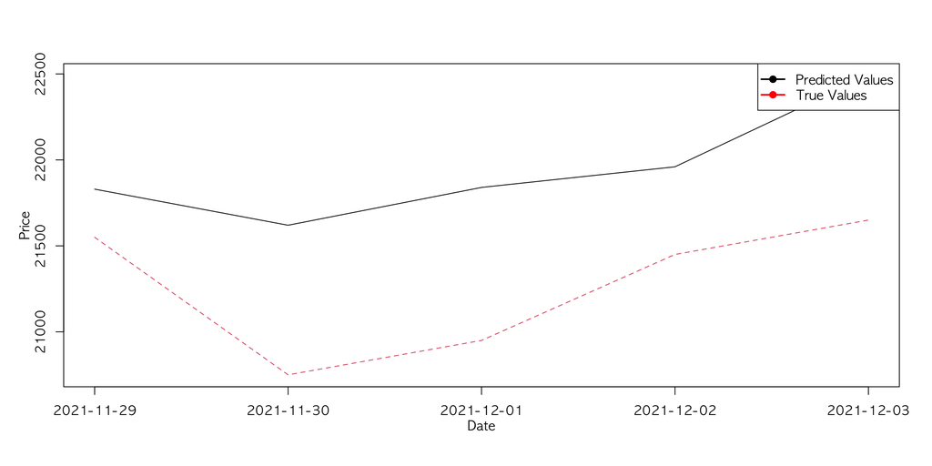

```r
matplot(cbind(predict_f, true_y), type = "l", xaxt = "n", ylab = "")

legend("topright", legend = c("Predicted Values","True Values"), lwd=2, pch = 19, col = c("black", "red"))

axis(1, at=c(1,2,3,4,5), lab=c("2021-11-29", "2021-11-30", "2021-12-01", "2021-12-02","2021-12-03"))

mtext(side = 1, "Date", line = 2)

mtext(side = 2, "Price", line = 2)
```

## 4.11 370개 예측 코드

```
{r eval=FALSE, include=TRUE}
stock_list=py$stock_list
for (i in 1:370){
  setwd("/Users/ps712/OneDrive/ps/Dacon/stock/data7")
  file=stock_list[i,2]

  total=read.csv(file)
  nrow=length(total[,2])

  rsi= data.frame(total["RSI_New"])
  cci=data.frame(total["CCI_New"])
  macd=data.frame(total["MACD_New"])
  r=data.frame(total["Return"])

  Input = matrix(c(as.numeric(rsi[1:(nrow-6),1]), as.numeric(cci[1:(nrow-6),1]), as.numeric(macd[1:(nrow-6),1])), nrow=(nrow-6))
  Target = matrix(c(r[2:(nrow-5),1]), nrow=(nrow-6))

  InputTest=matrix(c(as.numeric(rsi[(nrow-5):(nrow-1),1]), as.numeric(cci[(nrow-5):(nrow-1),1]), as.numeric(macd[(nrow-5):(nrow-1),1])),nrow=5)
  TargetTest=matrix(c(as.numeric(r[(nrow-4):(nrow),1])), nrow=5)

  trainingdata=cbind(Input, Target)
  colnames(trainingdata)=c("RSI", "CCI", "MACD", "Return")
  trainingdata=na.omit(trainingdata)


  Testdata=cbind(InputTest,TargetTest)
  colnames(Testdata)=c("RSI","CCI","MACD", "Return")

  length=length(trainingdata[,1])
  trainIndex <- createDataPartition(1:length, p=.8, list=F)
  Train <- trainingdata[trainIndex, ]
  Valid <- trainingdata[-trainIndex, ]

  best.network=matrix(0,2)
  best.mae=1

  for (i in seq(10, 100, 5)) for (j in c(0.01, 0.001, 0.0001)) {
    Fit=nnet(Return ~ RSI + CCI + MACD, data = Train, maxit=1000, size=i, decay=j, linout=TRUE)
    Predict=predict(Fit, newdata=Valid)
    mae1=mean(abs(Predict-Valid[,4]))
```

[output cut: 11 more lines]

```
   Fit=nnet(Return ~ RSI + CCI + MACD, data=trainingdata, maxit=100, size=best.network[1], decay=best.network[2], linout=TRUE)
   Predict1=Predict1 + predict(Fit, newdata=Testdata)
  }
  Predict1=Predict1/21 # Take average

  a=total["Price"][(nrow):(nrow),1]
  b= round(a * (1+Predict1[1,1]),-1)
  c= round(b * (1+Predict1[2,1]),-1)
  d= round(c * (1+Predict1[3,1]),-1)
  e= round(d * (1+Predict1[4,1]),-1)
  f= round(e * (1+Predict1[5,1]),-1)
  predict_f= c(b,c,d,e,f)

  setwd("/Users/ps712/OneDrive/ps/Dacon/stock/data8")
  write.zoo(predict_f, file=file,index.name=stock_list[i,2],row.names=FALSE, col.names=FALSE,sep=",")}
```

# 5 결과를 바탕으로한 action plan

모델링 결과 급등 또는 급락의 변동성의 크기는 잘예측되지 않았으나 그 방향은 비교적 예측이 잘되었으므로 하락이 예측되는 경우 매도 상승이 예측되는경우 추가매수 또는 홀드

# 6 한계점 및 향후 연구

(1)TTR패키지를 활용한 Indicator는 총 6가지인데 이중 3가지밖에 활용하지 못 하였음 대체적인 Indicator지표 활용방안 강구 필요  
(2)대회결과 상위권은 4%대 NMAE(평균절대오차)가 나왔으며 상기모델의 370개 NMAE값은 5.3%였음 그러나 위모델은 튜닝이 전혀되지 않은 베이스라인이라고 볼 수 있으므로 모델을 수정하면 더 좋은 결과가 나왔을것으로 예상함  
(3)대회종료기간에 임박하여 참가하였기 때문에 많은 시도를 못하였으나 추후 추가하고자하는 바는 아래와 같음  
- 상장종목 Segmentation 필요 예컨대 바이오,반도체, 배터리등 업종별로 분류하거나 지주회사 모회사 자회사등 지분관계로 분류 등 세분화하여 모델링 필요  
- 거래량, 유통주식수 등을 feature로 활용  
- 구글 트렌드 검색을 활용하여 변동성에 차가감하는 용도로 활용  
- 선행지표활용 예컨대 해당기업의 시장이 글로벌한 경우 미국주식의 종가를 선행지표로 활용가능 삼성전자의 경우 미국 반도체 주식인 마이크론과 상관계수가 높으며 한국전력의 경우 원유값을 선행지표로 활용 가능할 것으로 보임